# Project 1

Roland Fernandez

January 20, 2016

This page was produced from an R Markdown document that contains the code and description of the plot for project1.

## **A. Loading and preprocessing the data**

First, we load our data:

```r
df = read.csv("activity.csv")
summary(df)
```

```
##      steps                date          interval
##  Min.   :  0.00   2012-10-01:  288   Min.   :   0.0
##  1st Qu.:  0.00   2012-10-02:  288   1st Qu.: 588.8
##  Median :  0.00   2012-10-03:  288   Median :1177.5
##  Mean   : 37.38   2012-10-04:  288   Mean   :1177.5
##  3rd Qu.: 12.00   2012-10-05:  288   3rd Qu.:1766.2
##  Max.   :806.00   2012-10-06:  288   Max.   :2355.0
##  NA's   :2304     (Other)   :15840
```

## **B. What is mean total number of steps taken per day?**

Below, we group the data by day, computing the total number of steps for each day.

```r
agg = aggregate(df$steps, by=list(date=df$date), FUN=sum)
head(agg)
```

```
##         date     x
## 1 2012-10-01    NA
## 2 2012-10-02   126
## 3 2012-10-03 11352
## 4 2012-10-04 12116
## 5 2012-10-05 13294
## 6 2012-10-06 15420
```

Now, we plot the vector of total steps per day in a histogram to see the frequency distribution.

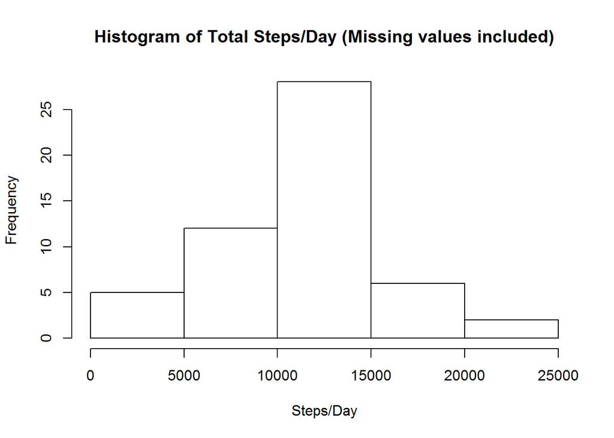

```r
hist(agg$x, main="Histogram of Total Steps/Day (Missing values included)", xlab="Steps/Day")
```

Here, we calculate the mean and median number of steps taken each day.

```r
mean(agg$x, na.rm=TRUE)
```

```
## [1] 10766.19
```

```r
median(agg$x, na.rm=TRUE)
```

```
## [1] 10765
```

## **C. What is the average daily activity pattern?**

Remove NA rows, average by interval, and create a line plot to display the results.

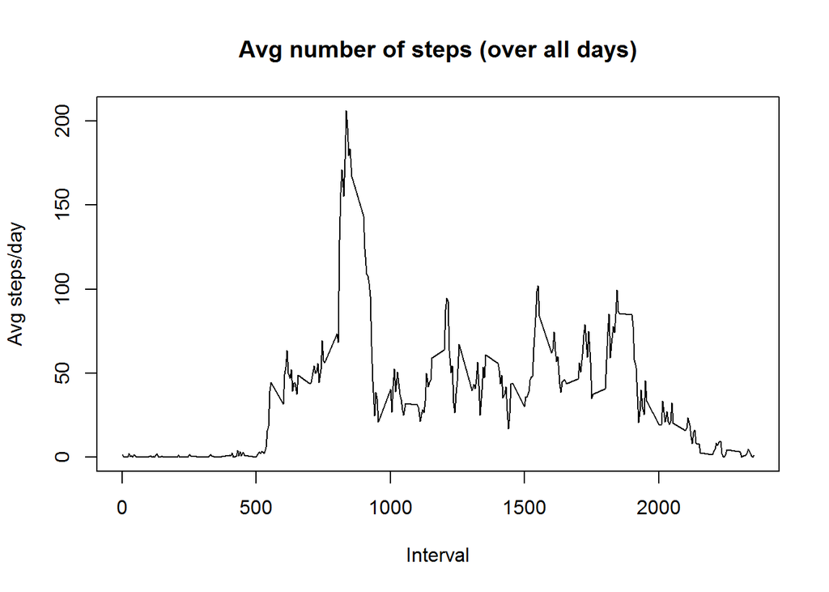

```r
df2 = df[!is.na(df$steps),]
agg = aggregate(df2$steps, list(df2$interval), mean)
plot(agg$x, x=agg$Group.1, type="l", xlab="Interval", ylab="Avg steps/day", main="Avg number of steps (over all days)")
```

Which 5-minute interval, as shown in the plot, contains the maximum number of steps?

```r
index = which.max(agg$x)
cat("the max steps=", agg$x[index], "can be found at interval=", agg$Group.1[index])
```

```
## the max steps= 206.1698 can be found at interval= 835
```

## **D. Imputing missing values**

Let’s calculate the total number of missing values in the dataset.

```r
sum(!complete.cases(df))
```

```
## [1] 2304
```

How many of those are in the steps column?

```r
sum(is.na(df$steps))
```

```
## [1] 2304
```

OK, let’s replace the na values in steps with the average for the 5 minute interval (already stored in “agg”).

```r
df3 = df
df3$steps = ifelse(is.na(df$steps), agg$x[match(df$interval, agg$Group.1)], df$steps)
```

As before, we group the data by day, computing the total number of steps for each day.

```r
agg3 = aggregate(df3$steps, by=list(date=df3$date), FUN=sum)
head(agg3)
```

```
##         date        x
## 1 2012-10-01 10766.19
## 2 2012-10-02   126.00
## 3 2012-10-03 11352.00
## 4 2012-10-04 12116.00
## 5 2012-10-05 13294.00
## 6 2012-10-06 15420.00
```

As before, we plot the vector of total steps per day in a histogram to see the frequency distribution.

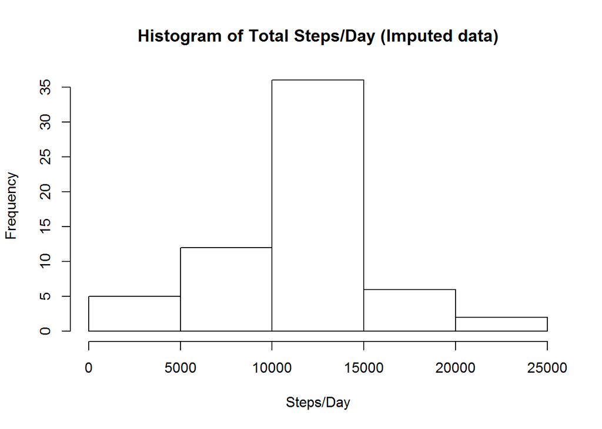

```r
hist(agg3$x, main="Histogram of Total Steps/Day (Imputed data)", xlab="Steps/Day")
```

Here, we calculate the mean and median number of steps taken each day.

```r
mean(agg3$x, na.rm=TRUE)
```

```
## [1] 10766.19
```

```r
median(agg3$x, na.rm=TRUE)
```

```
## [1] 10766.19
```

We see here the mean and median of the imputed data is the same as the mean of the original data, but the histogram shows that the frequencies have increased.

## **E. Are there differences in activity patterns between weekdays and weekends?**

Let’s add an “isWeekEnd” column, so we can compare weekend values to weekday values.

```r
df3$isWeekEnd = as.POSIXlt(df3$date)$wday %in% c(0, 6)
```

In preparation for building of plot of each, compute the aggregates of weekends, weekdays.

```r
df3a = df3[df3$isWeekEnd,]
agg3a = aggregate(df3a$steps, list(df3a$interval), mean)

df3b = df3[!df3$isWeekEnd,]
agg3b = aggregate(df3b$steps, list(df3b$interval), mean)
```

Now, create both plots.

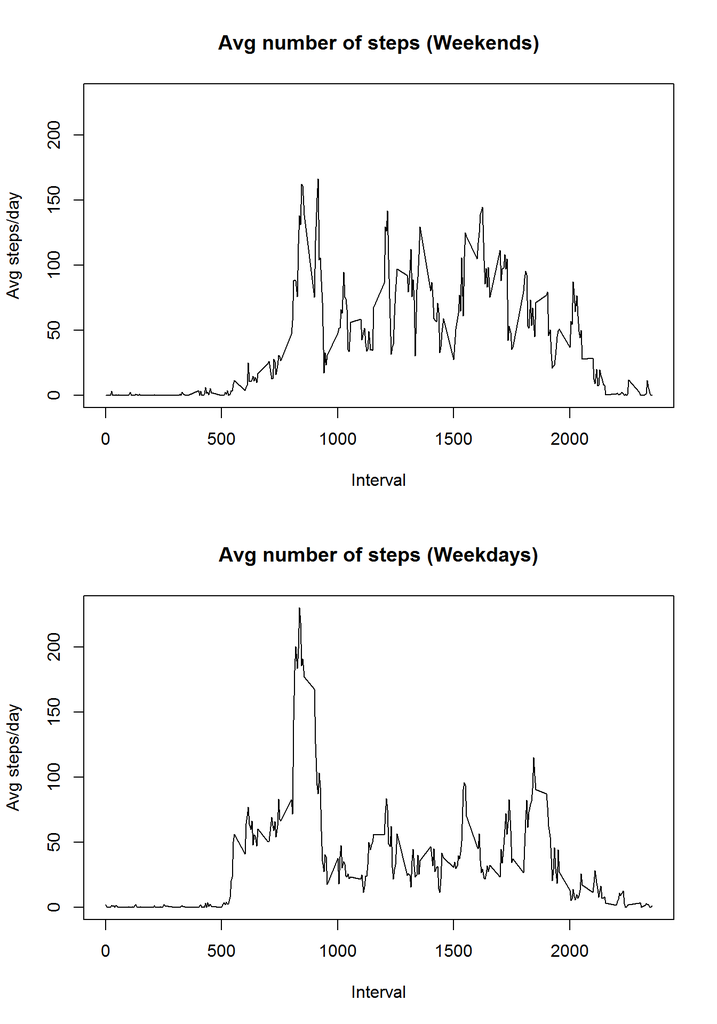

```r
par(mfrow=c(2,1))

## calculate the maxY value to use for both plots
maxY = max(max(agg3a$x), max(agg3b$x))

plot(agg3a$x, x=agg3a$Group.1, type="l", xlab="Interval", ylab="Avg steps/day", main="Avg number of steps (Weekends)", ylim=c(0, maxY))

plot(agg3b$x, x=agg3b$Group.1, type="l", xlab="Interval", ylab="Avg steps/day", main="Avg number of steps (Weekdays)",  ylim=c(0, maxY))
```